# Formulating the Optimum Concrete Mix Using Machine Learning

## 6. Machine Learning Using XGBoost

### 6.1 XGBoost on Original Data

We got a high $R^2$ accuracy of 92.52% with the Gradient Boosting Regressor. But can we go higher than that? To attempt to do so, we will make use of XGBoost, an improved implementation of the GBM.

```python
param_grid = {
    'learning_rate': [0.01, 0.1, 0.15],
    'max_depth': [3, 4, 5, 7, 10],
    'n_estimators': [100, 250, 500, 750]
}

estxg = XGBRegressor(random_state=0, silent=True)

gs_cv_xg = GridSearchCV(estxg, param_grid, cv=3, verbose=1).fit(df_features, target)
print(gs_cv_xg.best_params_)
```

```
Fitting 3 folds for each of 60 candidates, totalling 180 fits
```

```
[Parallel(n_jobs=1)]: Using backend SequentialBackend with 1 concurrent workers.
[Parallel(n_jobs=1)]: Done 180 out of 180 | elapsed:  1.1min finished
```

```
{'learning_rate': 0.15, 'max_depth': 3, 'n_estimators': 750}
```

```python
n_trials = 10
xgb_scores = []
for i in range(n_trials):
    X_train, X_test, y_train, y_test = train_test_split(df_features, target, test_size=0.25, random_state=i)
    xgbr = XGBRegressor(learning_rate=0.15, max_depth=3, n_estimators=750, random_state=0, silent=True)
    xgbr.fit(X_train, y_train)
    xgb_scores.append(xgbr.score(X_test, y_test))
```

```python
mean_xgb_score = np.mean(xgb_scores)
print('Average score of XGBoost over {} trials: {:.2f}%'.format(n_trials, mean_xgb_score*100))
```

```
Average score of XGBoost over 10 trials: 93.66%
```

Averaged over 10 trials, we were able to obtain an accuracy of **93.66%**, better than with GBM.

### 6.2 Applying Learnings: Testing the Water/Cement Ratio

At this point, we can compute the water-cement ratio in order to obtain a higher accuracy.

```python
df_features_eng = df_features.copy()
df_features_eng['wc_ratio'] = df_features_eng['water'] / df_features_eng['cement']
df_features_eng = df_features_eng.drop(columns=['water', 'cement'])
```

```python
n_trials = 10
xgb_scores = []
for i in range(n_trials):
    X_train, X_test, y_train, y_test = train_test_split(df_features_eng, target, test_size=0.25, random_state=i)
    xgbr_e = XGBRegressor(learning_rate=0.15, max_depth=3, n_estimators=750, random_state=0, silent=True)
    xgbr_e.fit(X_train, y_train)
    xgb_scores.append(xgbr_e.score(X_test, y_test))
mean_xgb_score = np.mean(xgb_scores)
print('Average score of XGBoost over {} trials: {:.2f}%'.format(n_trials, mean_xgb_score*100))
```

```
Average score of XGBoost over 10 trials: 94.20%
```

Indeed, doing this feature engineering slightly improves the accuracy. This is because simply adding more cement to the mix will not necessarily increase the strength, since every mass of concrete added needs to have a corresponding water mass added as well to hydrate it.

### 6.3 Final Results of the Machine Learning

From our Machine Learning runs, we were able to predict the strength of a concrete mix to an $R^2$ accuracy of **93.66%**.

The following model was used:

- XGBoosting Regressor (average over 10 trials) with the following hyperparameters:
  - `learning_rate` = 0.15
  - `max_depth` = 3
  - `n_estimators` = 750

When performing feature engineering (obtaining the water/cement ratio), we were able to bump the accuracy up slightly to **94.20%**.

#### Feature Importances (Original Data)

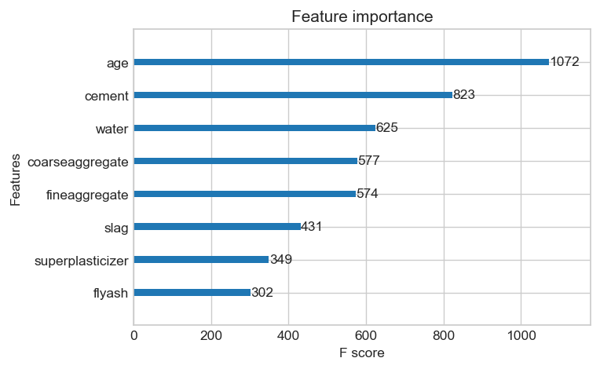

```python
fig, ax = plt.subplots(1, 1, dpi=125)
xgboost.plot_importance(xgbr, ax=ax)
plt.show()
```

#### Feature Importances (With Water-Cement Ratio)

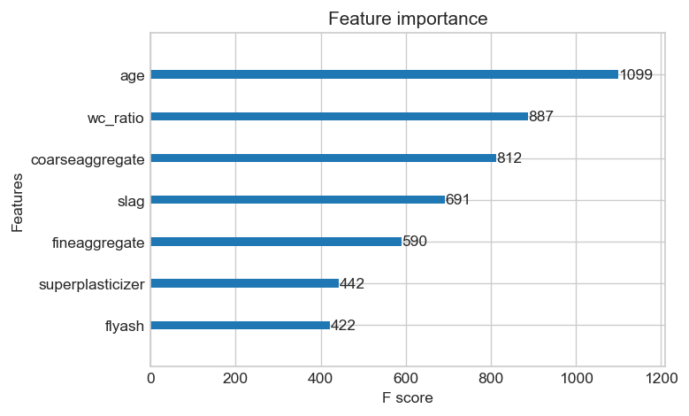

```python
fig, ax = plt.subplots(1, 1, dpi=125)
xgboost.plot_importance(xgbr_e, ax=ax)
plt.show()
```

Age is the most important feature, since concrete hardens over time. The water-concrete ratio is also important, as water and concrete collectively serve as the binder for the concrete, keeping it together. Notably, fly ash is the least important feature. This is a significant finding, as some cements market themselves as containing fly ash. Since fly ash contributes little to the compressive strength of cement, it might be functioning as a filler or extender for concrete. Thus, people should be prudent when purchasing cement that is advertised to have fly ash content.

## 7. Formulating the Optimum Concrete Mix

In section 6, we were able to create a highly accurate model that can predict the strength of a concrete mix with an accuracy of 94.20%.

For this section, our objective is to use the model that we have created to formulate the most economical concrete mix that can still achieve a certain compressive strength. By doing so, we can be able to help construction companies save on concrete costs and build more efficiently.

### 7.1 Ingredient Prices

Prices were canvassed to the best of the author's ability on August 2019.

| Name | Estimated Price per kg PHP |
| --- | --- |
| Cement (component 1) | 5.50 |
| Blast Furnace Slag (component 2) | 0.80 |
| Fly Ash (component 3) | 1.80 |
| Water (component 4) | 0.00 |
| Superplasticizer (component 5) | 150.00 |
| Coarse Aggregate (component 6) | 0.73 |
| Fine Aggregate (component 7) | 0.76 |

### 7.2 Mixing Round 1: Brute Force

One option for us to optimize an economical concrete mix is to iterate over the entire range of possible values for each of the ingredients using `itertools`. This is a brute force method; we iterate over all possible concrete mixes and get the price and compressive strength for each. The optimum concrete mix for a strength of, say, 40 MPa, will be the mix with the minimum price that has a strength of at least 40 MPa.

```python
cp = 5.5
sp = .8
fp = 1.8
wp = 0.
pp = 150.
gp = 0.73
sp = 0.76
```

```python
cement = np.arange(102, 540+1)
slag = np.arange(0, 359+1)
flyash = np.arange(0, 200+1)
water = np.arange(122, 247+1)
superplasticizer = np.arange(0, 32+1)
coarseaggregate = np.arange(801, 1145+1)
fineaggregate = np.arange(594, 992+1)
age = (28,)
```

```python
total_iters = len(cement)*len(slag)*len(flyash)*len(water)*len(superplasticizer)*len(coarseaggregate)*len(fineaggregate)*len(age)
total_iters
```

```
18181912114119600
```

```python
def price(x):
    return x[0]*cp+x[1]*sp+x[2]*fp+x[3]*wp+x[4]*pp+x[5]*gp+x[6]*sp

def strength(x):
    comp_str = xgbr_e.predict(pd.DataFrame({'slag': [x[1]],
                             'flyash': [x[2]],
                             'superplasticizer': [x[4]], 'coarseaggregate': [x[5]],
                            'fineaggregate': [x[6]], 'age': [28], 'wc_ratio': [x[3]/x[0]]}))[0]
    return comp_str
```

```python
# i = 1
# lowest_price = 50000
# for p in itertools.product(cement, slag, flyash, water, superplasticizer, coarseaggregate, fineaggregate, age):
#     x = p
#     cstr_ = strength(x)
#     price_ = price(x)
#     if not i % 1000:
#         print('Trial {} of {}'.format(i, total_iters))
#         print('--------------')
#         print('Progress: {:.2f}%'.format(i/total_iters*100))
#         clear_output(wait=True)
#     if cstr_ < 40.:
#         i += 1
#         continue
#     else:
#         if price_ < lowest_price:
#             best_mix = x
#             global_price = price_
#             global_strength = cstr_
#     i += 1
```

Although the code is ready, we see that there are 18181912114119600 total permutations, and iterating through all of them will take several lifetimes, if not an eternity. Even increasing the step of arange barely helps. Thus, we will not proceed with this analysis.

### 7.3 Mixing Round 2: Using Available Samples

We were unable to produce the optimum concrete mix through brute-force iteration. However, we already have a sample of about 1000 different concrete mixes in our data. Thus, we will get the most optimal among these samples.

Defining a function that calculates the price of each concrete mix:

```python
def get_prices(row):
    price = 0
    price += row['cement']*cp + row['slag']*sp + row['flyash']*fp
    price += row['water']*wp + row['superplasticizer']*pp
    price += row['coarseaggregate']*gp + row['fineaggregate']*sp
    return price
```

```python
prices = df.apply(lambda row: get_prices(row), axis=1)
df['price_php'] = prices
df.head()
```

|  | cement | slag | flyash | water | superplasticizer | coarseaggregate | fineaggregate | age | csMPa | price_php |
| --- | --- | --- | --- | --- | --- | --- | --- | --- | --- | --- |
| 0 | 540.0 | 0.0 | 0.0 | 162.0 | 2.5 | 1040.0 | 676.0 | 28 | 79.99 | 4617.960 |
| 1 | 540.0 | 0.0 | 0.0 | 162.0 | 2.5 | 1055.0 | 676.0 | 28 | 61.89 | 4628.910 |
| 2 | 332.5 | 142.5 | 0.0 | 228.0 | 0.0 | 932.0 | 594.0 | 270 | 40.27 | 3068.850 |
| 3 | 332.5 | 142.5 | 0.0 | 228.0 | 0.0 | 932.0 | 594.0 | 365 | 41.05 | 3068.850 |
| 4 | 198.6 | 132.4 | 0.0 | 192.0 | 0.0 | 978.4 | 825.5 | 360 | 44.30 | 2534.536 |

Below, we define a function that calculates the economy of a mix i.e. unit compressive strength provided per peso. Since the values will be very small, we will multiply this value by 1000, in effect taking the KiloPascals (KPa) provided per peso.

```python
def get_econ(row):
    econ = row['csMPa']*1000 / row['price_php']
    return econ
econ = df.apply(lambda row: get_econ(row), axis=1)
df['csKPa_per_php'] = econ
df.head()
```

|  | cement | slag | flyash | water | superplasticizer | coarseaggregate | fineaggregate | age | csMPa | price_php | csKPa_per_php |
| --- | --- | --- | --- | --- | --- | --- | --- | --- | --- | --- | --- |
| 0 | 540.0 | 0.0 | 0.0 | 162.0 | 2.5 | 1040.0 | 676.0 | 28 | 79.99 | 4617.960 | 17.321501 |
| 1 | 540.0 | 0.0 | 0.0 | 162.0 | 2.5 | 1055.0 | 676.0 | 28 | 61.89 | 4628.910 | 13.370318 |
| 2 | 332.5 | 142.5 | 0.0 | 228.0 | 0.0 | 932.0 | 594.0 | 270 | 40.27 | 3068.850 | 13.122179 |
| 3 | 332.5 | 142.5 | 0.0 | 228.0 | 0.0 | 932.0 | 594.0 | 365 | 41.05 | 3068.850 | 13.376346 |
| 4 | 198.6 | 132.4 | 0.0 | 192.0 | 0.0 | 978.4 | 825.5 | 360 | 44.30 | 2534.536 | 17.478544 |

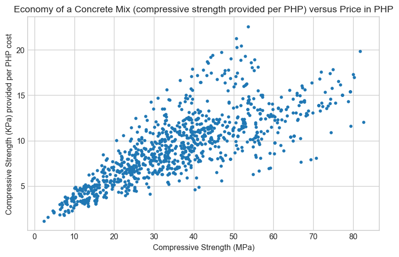

```python
plt.figure(figsize=(8, 5), dpi=115)
plt.plot(df['csMPa'], df['csKPa_per_php'], '.')
plt.title('Economy of a Concrete Mix (compressive strength provided per PHP) versus Price in PHP', fontsize=12)
plt.ylabel('Compressive Strength (KPa) provided per PHP cost')
plt.xlabel('Compressive Strength (MPa)')
plt.show()
```

We notice two things - as the compressive strength increases, the economy also improves, meaning that higher-strength concrete mixes are cheaper per unit strength provided. However, the data is also heteroskedastic - the spread of the data increases as compressive strength increases. This means that many inefficient mixes exist, and it is our task to identify the most economical mix per strength range.

```python
ini_lower_bound = 30
ini_upper_bound = 35
for i in range(11):
    lower_bound = ini_lower_bound + i*5
    upper_bound = ini_upper_bound + i*5
    opti = df[(df['csMPa'] >= lower_bound) & (df['csMPa'] < upper_bound)].sort_values('csKPa_per_php', ascending=False)
    display(HTML('<h4>7.3.{} Optimum Concrete Mix for Strength Range {} to {} MPa'.format(i+1, lower_bound, upper_bound)))
    display(opti.head(1))
    display(HTML('The ingredients for the optimum concrete Mix in the strength range {} to {} MPa are:'.format(lower_bound, upper_bound)))
    column_str = '<ul>'
    for col in opti.columns:
        if col != 'csMPa' and col != 'price_php' and col != 'csKPa_per_php' and col != 'age':
            column_str += '<li><b>{}</b>: {}kg</li>'.format(col, opti[col].iloc[0])
    column_str += '</ul>'
    display(HTML(column_str))
```

7.3.1 Optimum Concrete Mix for Strength Range 30 to 35 MPa

|  | cement | slag | flyash | water | superplasticizer | coarseaggregate | fineaggregate | age | csMPa | price_php | csKPa_per_php |
| --- | --- | --- | --- | --- | --- | --- | --- | --- | --- | --- | --- |
| 650 | 122.6 | 183.9 | 0.0 | 203.5 | 0.0 | 958.2 | 800.1 | 90 | 33.19 | 2121.626 | 15.643662 |

The ingredients for the optimum concrete Mix in the strength range 30 to 35 MPa are:

- **cement**: 122.6kg

- **slag**: 183.9kg

- **flyash**: 0.0kg

- **water**: 203.5kg

- **superplasticizer**: 0.0kg

- **coarseaggregate**: 958.2kg

- **fineaggregate**: 800.1kg

7.3.2 Optimum Concrete Mix for Strength Range 35 to 40 MPa

|  | cement | slag | flyash | water | superplasticizer | coarseaggregate | fineaggregate | age | csMPa | price_php | csKPa_per_php |
| --- | --- | --- | --- | --- | --- | --- | --- | --- | --- | --- | --- |
| 715 | 141.3 | 212.0 | 0.0 | 203.5 | 0.0 | 971.8 | 748.5 | 90 | 39.66 | 2216.544 | 17.892719 |

The ingredients for the optimum concrete Mix in the strength range 35 to 40 MPa are:

- **cement**: 141.3kg

- **slag**: 212.0kg

- **flyash**: 0.0kg

- **water**: 203.5kg

- **superplasticizer**: 0.0kg

- **coarseaggregate**: 971.8kg

- **fineaggregate**: 748.5kg

7.3.3 Optimum Concrete Mix for Strength Range 40 to 45 MPa

|  | cement | slag | flyash | water | superplasticizer | coarseaggregate | fineaggregate | age | csMPa | price_php | csKPa_per_php |
| --- | --- | --- | --- | --- | --- | --- | --- | --- | --- | --- | --- |
| 66 | 139.6 | 209.4 | 0.0 | 192.0 | 0.0 | 1047.0 | 806.9 | 360 | 44.7 | 2304.498 | 19.396849 |

The ingredients for the optimum concrete Mix in the strength range 40 to 45 MPa are:

- **cement**: 139.6kg

- **slag**: 209.4kg

- **flyash**: 0.0kg

- **water**: 192.0kg

- **superplasticizer**: 0.0kg

- **coarseaggregate**: 1047.0kg

- **fineaggregate**: 806.9kg

7.3.4 Optimum Concrete Mix for Strength Range 45 to 50 MPa

|  | cement | slag | flyash | water | superplasticizer | coarseaggregate | fineaggregate | age | csMPa | price_php | csKPa_per_php |
| --- | --- | --- | --- | --- | --- | --- | --- | --- | --- | --- | --- |
| 51 | 190.0 | 190.0 | 0.0 | 228.0 | 0.0 | 932.0 | 670.0 | 180 | 46.93 | 2378.96 | 19.727108 |

The ingredients for the optimum concrete Mix in the strength range 45 to 50 MPa are:

- **cement**: 190.0kg

- **slag**: 190.0kg

- **flyash**: 0.0kg

- **water**: 228.0kg

- **superplasticizer**: 0.0kg

- **coarseaggregate**: 932.0kg

- **fineaggregate**: 670.0kg

7.3.5 Optimum Concrete Mix for Strength Range 50 to 55 MPa

|  | cement | slag | flyash | water | superplasticizer | coarseaggregate | fineaggregate | age | csMPa | price_php | csKPa_per_php |
| --- | --- | --- | --- | --- | --- | --- | --- | --- | --- | --- | --- |
| 34 | 190.0 | 190.0 | 0.0 | 228.0 | 0.0 | 932.0 | 670.0 | 365 | 53.69 | 2378.96 | 22.568685 |

The ingredients for the optimum concrete Mix in the strength range 50 to 55 MPa are:

- **cement**: 190.0kg

- **slag**: 190.0kg

- **flyash**: 0.0kg

- **water**: 228.0kg

- **superplasticizer**: 0.0kg

- **coarseaggregate**: 932.0kg

- **fineaggregate**: 670.0kg

7.3.6 Optimum Concrete Mix for Strength Range 55 to 60 MPa

|  | cement | slag | flyash | water | superplasticizer | coarseaggregate | fineaggregate | age | csMPa | price_php | csKPa_per_php |
| --- | --- | --- | --- | --- | --- | --- | --- | --- | --- | --- | --- |
| 30 | 304.0 | 76.0 | 0.0 | 228.0 | 0.0 | 932.0 | 670.0 | 365 | 55.26 | 2919.32 | 18.929066 |

The ingredients for the optimum concrete Mix in the strength range 55 to 60 MPa are:

- **cement**: 304.0kg

- **slag**: 76.0kg

- **flyash**: 0.0kg

- **water**: 228.0kg

- **superplasticizer**: 0.0kg

- **coarseaggregate**: 932.0kg

- **fineaggregate**: 670.0kg

7.3.7 Optimum Concrete Mix for Strength Range 60 to 65 MPa

|  | cement | slag | flyash | water | superplasticizer | coarseaggregate | fineaggregate | age | csMPa | price_php | csKPa_per_php |
| --- | --- | --- | --- | --- | --- | --- | --- | --- | --- | --- | --- |
| 382 | 505.0 | 0.0 | 60.0 | 195.0 | 0.0 | 1030.0 | 630.0 | 28 | 64.02 | 4116.2 | 15.55318 |

The ingredients for the optimum concrete Mix in the strength range 60 to 65 MPa are:

- **cement**: 505.0kg

- **slag**: 0.0kg

- **flyash**: 60.0kg

- **water**: 195.0kg

- **superplasticizer**: 0.0kg

- **coarseaggregate**: 1030.0kg

- **fineaggregate**: 630.0kg

7.3.8 Optimum Concrete Mix for Strength Range 65 to 70 MPa

|  | cement | slag | flyash | water | superplasticizer | coarseaggregate | fineaggregate | age | csMPa | price_php | csKPa_per_php |
| --- | --- | --- | --- | --- | --- | --- | --- | --- | --- | --- | --- |
| 754 | 540.0 | 0.0 | 0.0 | 173.0 | 0.0 | 1125.0 | 613.0 | 90 | 69.66 | 4257.13 | 16.363137 |

The ingredients for the optimum concrete Mix in the strength range 65 to 70 MPa are:

- **cement**: 540.0kg

- **slag**: 0.0kg

- **flyash**: 0.0kg

- **water**: 173.0kg

- **superplasticizer**: 0.0kg

- **coarseaggregate**: 1125.0kg

- **fineaggregate**: 613.0kg

7.3.9 Optimum Concrete Mix for Strength Range 70 to 75 MPa

|  | cement | slag | flyash | water | superplasticizer | coarseaggregate | fineaggregate | age | csMPa | price_php | csKPa_per_php |
| --- | --- | --- | --- | --- | --- | --- | --- | --- | --- | --- | --- |
| 828 | 522.0 | 0.0 | 0.0 | 146.0 | 0.0 | 896.0 | 896.0 | 28 | 74.99 | 4206.04 | 17.829122 |

The ingredients for the optimum concrete Mix in the strength range 70 to 75 MPa are:

- **cement**: 522.0kg

- **slag**: 0.0kg

- **flyash**: 0.0kg

- **water**: 146.0kg

- **superplasticizer**: 0.0kg

- **coarseaggregate**: 896.0kg

- **fineaggregate**: 896.0kg

7.3.10 Optimum Concrete Mix for Strength Range 75 to 80 MPa

|  | cement | slag | flyash | water | superplasticizer | coarseaggregate | fineaggregate | age | csMPa | price_php | csKPa_per_php |
| --- | --- | --- | --- | --- | --- | --- | --- | --- | --- | --- | --- |
| 0 | 540.0 | 0.0 | 0.0 | 162.0 | 2.5 | 1040.0 | 676.0 | 28 | 79.99 | 4617.96 | 17.321501 |

The ingredients for the optimum concrete Mix in the strength range 75 to 80 MPa are:

- **cement**: 540.0kg

- **slag**: 0.0kg

- **flyash**: 0.0kg

- **water**: 162.0kg

- **superplasticizer**: 2.5kg

- **coarseaggregate**: 1040.0kg

- **fineaggregate**: 676.0kg

7.3.11 Optimum Concrete Mix for Strength Range 80 to 85 MPa

|  | cement | slag | flyash | water | superplasticizer | coarseaggregate | fineaggregate | age | csMPa | price_php | csKPa_per_php |
| --- | --- | --- | --- | --- | --- | --- | --- | --- | --- | --- | --- |
| 381 | 315.0 | 137.0 | 0.0 | 145.0 | 5.9 | 1130.0 | 745.0 | 28 | 81.75 | 4112.72 | 19.877356 |

The ingredients for the optimum concrete Mix in the strength range 80 to 85 MPa are:

- **cement**: 315.0kg

- **slag**: 137.0kg

- **flyash**: 0.0kg

- **water**: 145.0kg

- **superplasticizer**: 5.9kg

- **coarseaggregate**: 1130.0kg

- **fineaggregate**: 745.0kg

## 8. Conclusion and Recommendation

In attempting to predict the strength of a concrete mix solely from its ingredients, we were able to obtain an $R^2$ accuracy of **93.66%**, averaged over 10 trials, using XGBoost. This means that concrete compressive strength is quite predictable as early as when it is mixed. Most of the error may be attributable to inconsistencies in the mixing process - concrete strength is not solely dependent on its ingredients, since it can be affected by poor mixing, the ambient temperature, and other factors. Nevertheless, a 94% accuracy is quite high and we can confidently say that it is possible to reliably predict the strength of a concrete mix. This can be very useful, especially because the prevailing method for computing concrete strength (not testing but computing) is very tedious and prone to inaccuracy.

However, I would not advocate this method as a substitute for proper materials testing such as actual measuring of concrete strength by crushing. This is because many factors affect the strength of concrete, particularly the mixing procedure. It is possible to formulate a concrete mix that has an expected strength of 70 MPa, and only obtain 50 MPa in actuality.

## 9. Acknowledgments

- Jude Teves, for the sklearn wrapper
- Radney Racela for his work on improving the sklearn wrapper especially with the aesthetic redesign using `tqdm`.
- Ray Franco Rivera, for discussions on feature engineering.

## 10. References

- Design of Reinforced Concrete, Tenth Edition. 2016. Jack C. McCormac, Russell H. Brown. John Wiley & Sons.
- https://www.cement.org/cement-concrete-applications/concrete-materials/chemical-admixtures

### 10.1 Images

https://www.giatecscientific.com/education/concrete-mix-design-just-got-easier/